# GENE360 tutorial

Exploring the genetic diversity of human populations

Professor Mik Black

27 August 2025

## Overview

The objective of this module is to give you some familiarity with the types of data and tools that are commonly used for genetic studies of population diversity.

HMTL rendered version (slightly nicer looking) of this document is available at:

https://github.com/mikblack/GENE360-PopDiv/blob/master/GENE360-popDiv.md

The data we will be using are publicly available high-throughput sequencing data from the 1000 Genomes Project. The main web page for the 1000 Genomes Project is:

http://www.internationalgenome.org/

The following page provides background information about the 1000 Genomes Project:

http://www.internationalgenome.org/about/

and this one provides information about the populations being used in the study:

https://ftp.1000genomes.ebi.ac.uk/vol1/ftp/README_populations.md

We will be using the R and RStudio software applications to analyze the data (see separate PDF on Blackboard for software installation instructions).

### Getting started - loading the data

To get started, we need to load some data. I have placed a zip file containing the data files on the GENE360 Blackboard page. Download and unzip this file - it should create a folder called **GENE360_1000_genomes** which contains all the files we need. Move this to wherever you would like it on your computer (or just leave it where it is if that works for you) - next we need to tell RStudio where to find the data. The easiest way to do that is to create an R project.

To do this, select “New Project” from the File menu, then select “Existing Directory” and use the “Browse” button to select the **GENE360_1000_genomes** folder. Once you’ve done this, click “Create Project”.

R will now restart, and you should see the contents of the **GENE360_1000_genomes** folder display in the “Files” tab in the panel on the botom right of the RStudio application.

Choose “New File” and then “R Script” from the file menu - this will open a blank file where you can save your R commands. Save this new as something informative (e.g., “gene360-tutorial.R”) - the new file should now appear in the “Files” panel.

The first data set we will look at contains genetic data on just a few loci (specific points in the genome) across the various populations being studied. Looking at this small data set will give you a feel for what we mean by “genotype data” for a particular locus.

Read in the first data set using the following command:

```r
## Read in the SNP data
snpData = read.table('GENE360snpData.txt',sep='\t',header=T)
```

The `##` characters indicate a comment - anything typed after them is ignored by R. The next line tells R to read in data from the file “GENE360snpData.txt”, which it calls “snpData”.

Save the commands you use in the file you created above. You can run a command from your file by moving the cursor to that line, and then holding down “Command” and “Enter” (on a Mac) or “Control” and “Enter” (Mac and Windows).

In this handout, the “code” used to run commands in R (and any output produced) is indicated by `courier font`. The “output” from each command appears below the code, prefixed by the `##` symbols.

We can ask R about the characteristics of the snpData object. The command:

```r
dim(snpData)
```

```
## [1] 2504    9
```

will tell us how many rows (individuals) and columns the data set contains. The output shows us that there are 2504 rows and 9 columns.

The column names can be found using the following command:

```r
names(snpData)
```

```
## [1] "SubjectID"  "Population" "rs3826656"  "rs13387042" "rs4779584"
## [6] "rs2398162"  "rs1344706"  "rs7659604"  "rs734553"
```

To look at the full data set, you can use the “View” command:

```r
## Can view the data file within RStudio via
View(snpData)
```

The second column is called “Population”. We can make a table of this information to see how many individuals are present in each population (the “$” sign tells R to use the “Population” column from the “snpData”” object):

```r
table(snpData$Population)
```

```
##
## AFR AMR EAS EUR SAS
## 661 347 504 503 489
```

The super-population codes are:

AFR, African; AMR, Ad-Mixed American; EAS, East Asian; EUR, European; SAS, South Asian.

Additional information about the composition of these populations can be found at:

http://www.internationalgenome.org/faq/which-populations-are-part-your-study

## Looking at SNP frequencies

The other seven columns in the data set relate to specific single nucleotide polymorphisms (SNPs) in the genome - we have the genotype data for each SNP for every individual in the data set.

We can use the “table” command again to summarize the genotype information for each SNP:

```r
## Make a genotype frequency table for the first SNP
table(snpData$rs3826656)
```

```
##
##   AA   AG   GG
## 1112  952  440
```

We can also calculate the proportions associated with each genotype:

```r
## Calculate proportions
prop.table(table(snpData$rs3826656))
```

```
##
##        AA        AG        GG
## 0.4440895 0.3801917 0.1757188
```

and examine differences in genotype frequencies across populations:

```r
## Create contingeny table - genotypes across populations
table(snpData$Population, snpData$rs3826656)
```

```
##
##        AA  AG  GG
##   AFR 445 199  17
##   AMR 225 109  13
##   EAS  47 224 233
##   EUR 312 161  30
##   SAS  83 259 147
```

```r
## And calculate proportions (rounded)
round(prop.table(table(snpData$Population, snpData$rs3826656),1),2)
```

```
##
##         AA   AG   GG
##   AFR 0.67 0.30 0.03
##   AMR 0.65 0.31 0.04
##   EAS 0.09 0.44 0.46
##   EUR 0.62 0.32 0.06
##   SAS 0.17 0.53 0.30
```

These results can be plotted as a bar plot:

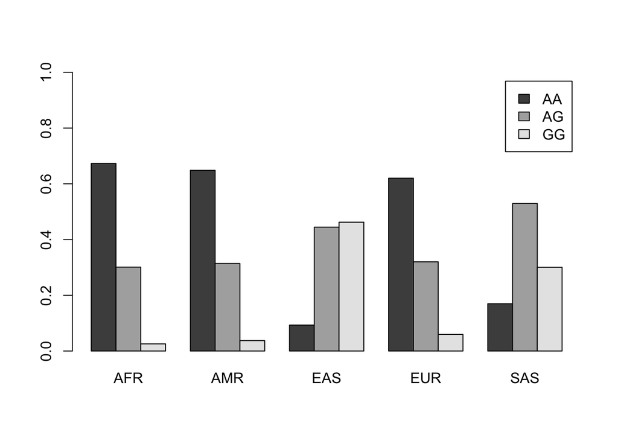

```r
snpFreqs = t(prop.table(table(snpData$Population, snpData$rs3826656), 1))
barplot(snpFreqs, beside=TRUE, legend.text=TRUE, ylim=c(0,1))
```

These analyses can be repeated for different SNPs by changing the SNP ID (e.g., rs3826656) in the above commands.

### Why look at these SNPs?

The seven SNPs contained in this data set were not just randomly chosen - they are SNPs that have been found to be associated with altered disease risk. That is, an individual’s genotype at a particular position in the genome affects their risk of developing a particular disease. This is not absolute though, it really just raises or lowers the probability of disease - it doesn’t guarantee complete protection or susceptibility.

| SNP | Link | Alleles | Nearby Gene | Disease |
| --- | --- | --- | --- | --- |
| rs3826656 | http://www.snpedia.com/index.php/Rs3826656 | A/G | CD33 | Alzheimer’s Disease |
| rs13387042 | http://www.snpedia.com/index.php/Rs13387042 | A/G | DIRC3 | Breast Cancer |
| rs4779584 | http://www.snpedia.com/index.php/Rs4779584 | T/C | GREM1 | Colorectal Cancer |
| rs2398162 | http://www.snpedia.com/index.php/Rs2398162 | A/G | NR2F2 | Hypertension |
| rs1344706 | http://www.snpedia.com/index.php/Rs1344706 | A/C | ZNF408A | Schizophrenia and Bipolar Disorder |
| rs7659604 | http://www.snpedia.com/index.php/Rs7659604 | T/C | TMEM155 | Type 2 Diabetes |
| rs734553 | http://www.snpedia.com/index.php/Rs734553 | T/G | SLC2A9 | Gout |

For each SNP, increased risk of disease is associated with the minor allele. Variation in genotype frequencies across populations can help to explain some of the population-specific differences in rates of different diseases.

Clicking on SNP IDs in the table above will link through to aditional information about each variant.

## Population diversity

The second data set that we will look at can be used to investigate population (genetic) diversity. These SNPs were chosen because they are “ancestry informative” - variation in their genotype frequencies tends to be associated with differences between population groups.

```r
## Load ancestry data
snpAns = read.table('GENE360snpAncestry.txt', header=T, sep='\t')
## Check dimensionality of data
dim(snpAns)
```

```
## [1] 2504 2305
```

Now we have a lot more data: 2504 individuals, and 2302 SNP genotypes for each. Note that there are 2305 columns in the data set, but the first three relate to non-SNP data.

Have a look using the View command:

```r
## Can view the data file within RStudio via
View(snpAns)
```

Note that we also have data about the sub-populations now:

```r
table(snpAns$SubPopulation, snpAns$Population)
```

```
##
##           AFR AMR EAS EUR SAS
##   AFR_ACB  96   0   0   0   0
##   AFR_ASW  61   0   0   0   0
##   AFR_ESN  99   0   0   0   0
##   AFR_GWD 113   0   0   0   0
##   AFR_LWK  99   0   0   0   0
##   AFR_MSL  85   0   0   0   0
##   AFR_YRI 108   0   0   0   0
##   AMR_CLM   0  94   0   0   0
##   AMR_MXL   0  64   0   0   0
##   AMR_PEL   0  85   0   0   0
##   AMR_PUR   0 104   0   0   0
##   EAS_CDX   0   0  93   0   0
##   EAS_CHB   0   0 103   0   0
##   EAS_CHS   0   0 105   0   0
##   EAS_JPT   0   0 104   0   0
##   EAS_KHV   0   0  99   0   0
##   EUR_CEU   0   0   0  99   0
##   EUR_FIN   0   0   0  99   0
##   EUR_GBR   0   0   0  91   0
##   EUR_IBS   0   0   0 107   0
##   EUR_TSI   0   0   0 107   0
##   SAS_BEB   0   0   0   0  86
##   SAS_GIH   0   0   0   0 103
##   SAS_ITU   0   0   0   0 102
##   SAS_PJL   0   0   0   0  96
##   SAS_STU   0   0   0   0 102
```

To examine population diversity, we need to do two things:

1. create a data object of ONLY the SNP genotype data (i.e., remove the first three columns).
2. convert the genotypes to allele counts (e.g., TT, AT, AA to 0, 1, 2 - count the number of A’s).

Step 1:

```r
## Create object containing only the SNP data - remove the first three columns
snpAnsDat = snpAns[,-c(1,2,3)]
```

Step 2:

```r
## Load a custom function to convert to allele counts
source('alleleCounts.R')

## Apply the function to the genotype data, one column (SNP) at a time
## This will take 30 seconds or so...
snpAnsCount = apply(snpAnsDat, 2, alleleCounts)
```

Now we have a data set of just the SNP data, with genotypes converted to allele counts.

Have a look at the new data set using the View command:

```r
View(snpAnsCount)
```

So, what are we going to do with this new data set?

### Dimension reduction (principal components analysis)

In terms of examining population diversity, we have 2302 dimensions of data available - one dimension for each SNP.

Rather than trying to comprehend this huge amount of data in 2302-dimensional space, genetics researchers often use a statistical tool called Principal Components Analysis (PCA) to reduce the dimensionality of the data.

The idea is to find the most important variation in the data, and examine the samples in terms of that variation, ignoring the rest. In practice, this works fairly well, because genetic differences between populations provide a strong (and relatively consistent) source of variation across genomic loci (i.e., SNPs). Rather than looking at 2302 dimensions of data, we end up looking at variation across just 2 or 3 dimensions - each dimension is defined by a combination of SNPs which vary in a similar way across the individuals in the study.

```r
## Load custom function to perform principal components analysis
source("pcaGenotypes.R")

## Apply this function to the allele count data
## This will take a couple of minutes to run
pca = pcaGenotypes(snpAnsCount)
```

To visualise the populations across the principal components, we need to define colours for each populations. My arbitrary choice (slightly influenced by the papers from last week) was: AFR (brown), AMR (red), EAS (purple), EUR (blue), SAS (green).

```r
## Create an object relating to the population data
ansPop = snpAns$Population

## Generate colours to associate with each population
pCols = c("brown","red","purple","blue","green")
popCol = pCols[as.numeric(as.factor(ansPop))]
names(popCol) = ansPop

## Check that they correspond to populations
table(popCol,ansPop)
```

```
##         ansPop
## popCol   AFR AMR EAS EUR SAS
##   blue     0   0   0 503   0
##   brown  661   0   0   0   0
##   green    0   0   0   0 489
##   purple   0   0 504   0   0
##   red      0 347   0   0   0
```

Now we can plot the principal components and colour the points based on the population each sample belongs to.

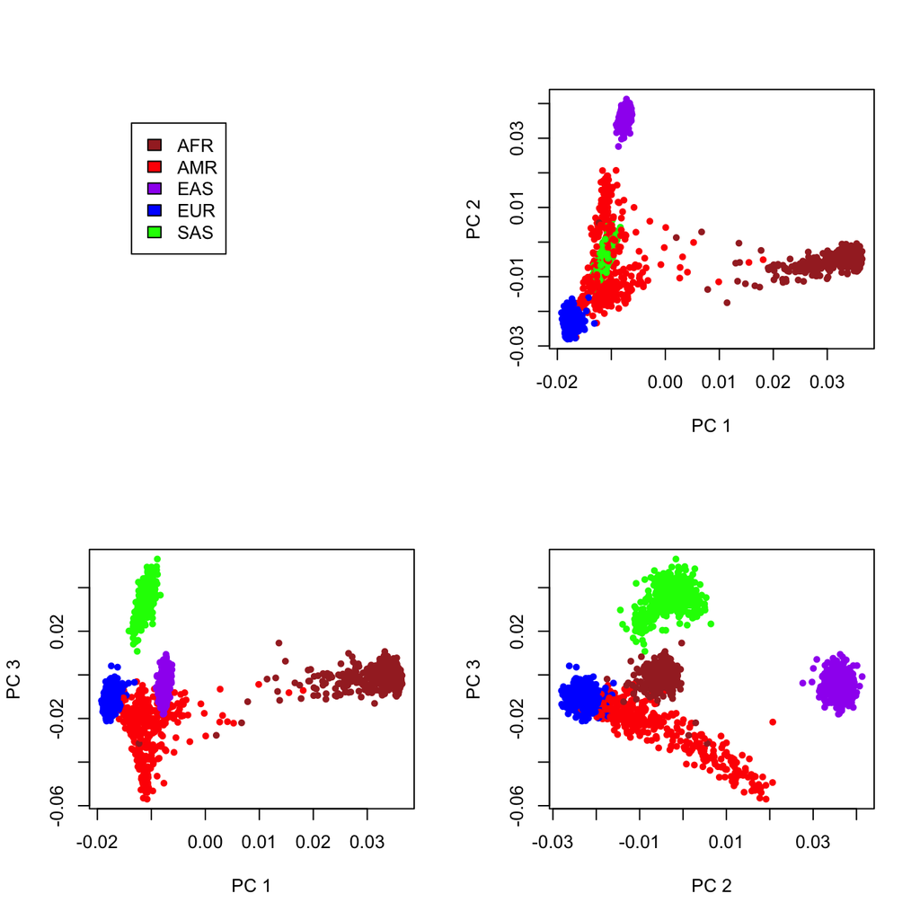

```r
## Load a custom plotting function to generate the plots:
source('plotPCA.R')

## Plot the PCA data that we have generated, along with the population information
plotPCA(pca, popCol)
```

From the plots we can see that samples from the same population tend to cluster together, and that the first three principal components do a reasonable job of capturing the genetic diversity between the populations.

By installing the `scatterplot3d` package, you can plot the first three principal components at once (i.e., combining the information from the three scatterplots above).

Install the package via:

```r
install.packages('scatterplot3d')
```

Note - you only have to run the above code once. After you’ve installed the package, you can load it into your R workspace via the `library` command.

This shows that the European (EUR), East Asian (EAS) and South Asian (SAS) super-populations are relatively homogeneous, while the Ad-Mixed American (AMR) and African (AFR) super-populations exhibit greater variation, suggesting admixture within these groups.

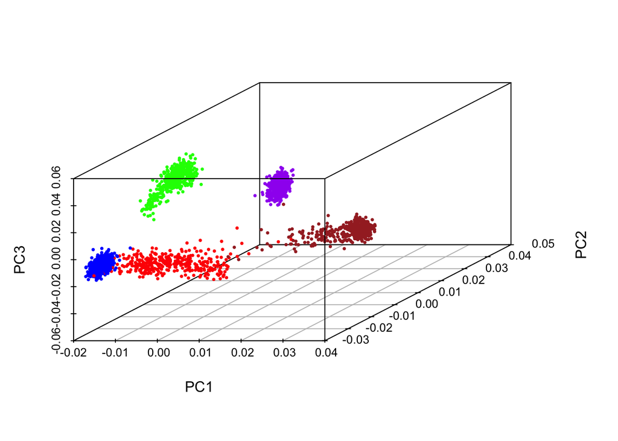

```r
library(scatterplot3d)
scatterplot3d(pca[,1], pca[,2], pca[,3], color=popCol, pch=16,
              cex.symbols=0.5, xlab="PC1", ylab="PC2", zlab="PC3")
```

## Phylogenetic trees

Another way to visualise genetic similarity is via “phylogenetic trees”, also known more generally as “dendrograms”.

These tree diagrams group items together based on similarity scores. In this setting our “items” are the populations, and the scores are calculated based on the genetic similarities between each pair of populations.

To calculate similarities, we need to create a set of “average” genotypes for each population. One way to do this is to calculate the frequency of the major homozygote for each SNP in each population.

```r
## Load custom function for calculating major homozygote frequency:
source('calcMajorFreq.R')

## Apply this function to the SNP count data
## Takes a few seconds
popFreqs = calcMajorFreq(snpAnsCount, ansPop)
```

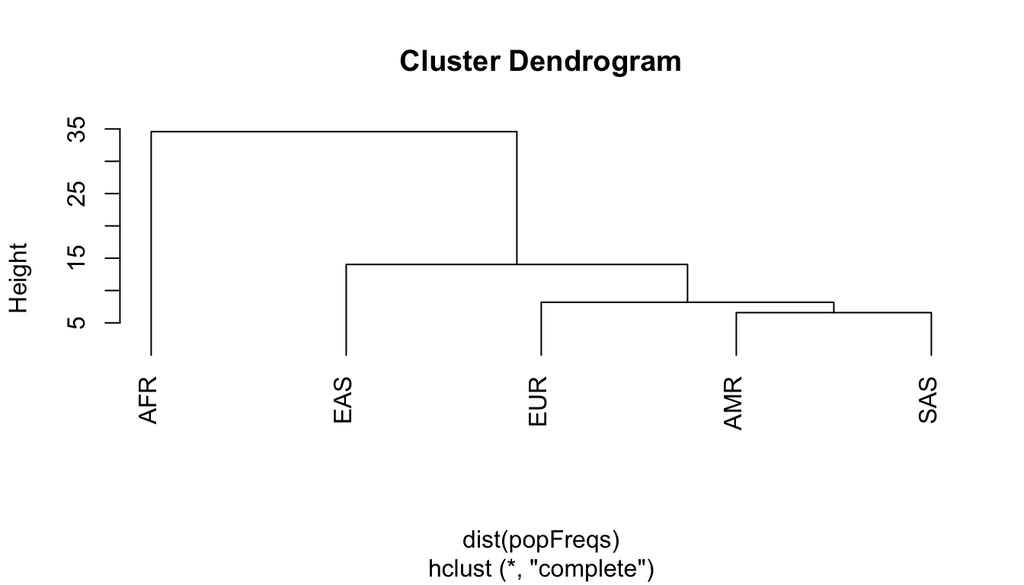

```r
## Make a cluster tree based on these frequencies
plot(hclust(dist(popFreqs)),hang=-1)
```

The way in which the “leaves” of the tree cluster, reflects the similarity between the items analysed. In this case the populations are grouped based on their genetic similarity, as measured by these particular loci. Here it appears that the AMR (Ad-Mixed American), and SAS (South Asian) super-populations are most genetically similar, then EUR (European), followed by EAS (East Asian). The AFR (African) super-population is the most genetically dissimilar relative to the others. It is likely that these groupings reflect (to some degree) migration patterns and shared ancestry experienced by these populations.

## Admixture

We can also use the PCA data to explore admixture in the 1000 Genomes populations.

Looking at he PCA plots we made above, it is fairly clear the the first principal component (PC1) relates to genetic variation that distinguishs the African super-population for the other super-populations.

A very simple approach to looking at admixture involving African ancestry would be to rescale PC1 so that it provides an estimate of African ancestry for each individual.

**Note:** this is a very crude and simplified method for exploring admixture - in a research setting we would use more sophisiticated approaches to investigate individuals’ genetic ancestries.

```r
## Get the data for PC1 (first column of the PCA matrix)
pc1 = pca[,1]

## Rescale the PC1 data so that it is on the 0-1 scale
## (subtract the minimum, and divide through by the new maximum)
pc1Prop = ( pc1 - min(pc1) ) / max( pc1 - min(pc1) )

## Check the results
range(pc1Prop)
```

```
## [1] 0 1
```

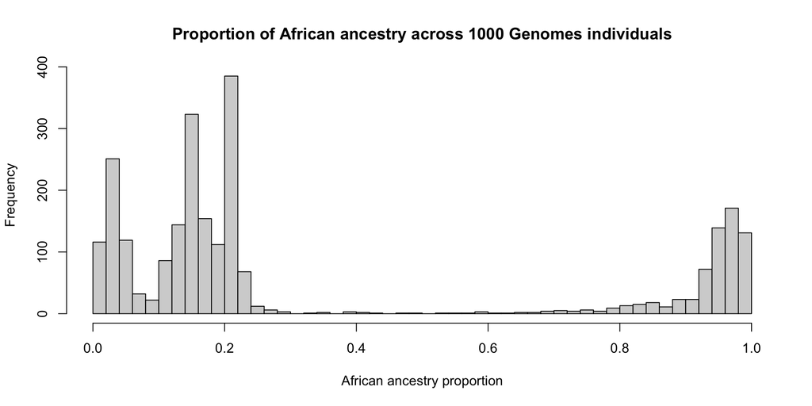

```r
## And plot
hist(pc1Prop, 50, xlab="African ancestry proportion",
     main="Proportion of African ancestry across 1000 Genomes individuals")
```

We can also look at this per subpopulation. Here is a summary of the admixture proportions based on PC1 for the AFR_ESN subpopulation:

```r
## Create new variable for subpopulations (just to make coding easier)
subPop = snpAns$SubPopulation

## Have a look at African ancestry proportion for AFR_ESN subpopulation
summary( pc1Prop[subPop=="AFR_ESN"] )
```

```
##    Min. 1st Qu.  Median    Mean 3rd Qu.    Max.
##  0.9613  0.9740  0.9781  0.9784  0.9829  0.9950
```

It looks like this subpopulation has very low levels of admixture (and uniformly high levels of African ancestry).

How about the AFR_ASW subpopulation?

```r
## Have a look at African ancestry proportion for AFR_ASW subpopulation
summary( pc1Prop[subPop=="AFR_ASW"] )
```

```
##    Min. 1st Qu.  Median    Mean 3rd Qu.    Max.
##  0.1249  0.7066  0.8033  0.7558  0.8438  0.9318
```

Here it looks like there is more evidence of admixture. Lets try to reproduce the style of the admixture bar plots we saw last week. First we need to create a matrix of data where the rows sum to 1 for each individual.

```r
## Create a matrix where the rows sum to one per individual (i.e., column):
admix = rbind(pc1Prop, 1-pc1Prop)

## Add row names
rownames(admix) = c("African ancestry", "Non-African ancestry")

## Admixture data for first five individuals
admix[, 1:5]
```

```
##                           [,1]      [,2]       [,3]      [,4]      [,5]
## African ancestry     0.8207639 0.2205823 0.01520012 0.1343279 0.1182994
## Non-African ancestry 0.1792361 0.7794177 0.98479988 0.8656721 0.8817006
```

Extract data for AFR_ASW population, and sort it based on level of African genetic ancestry:

```r
## Extract data for ASW population
asw_admix = admix[, subPop=="AFR_ASW"]

## Sort inidividuals based on level of African genetic ancestry
asw_admix = asw_admix[, order(asw_admix[1,])]
```

And now we can make the bar plot:

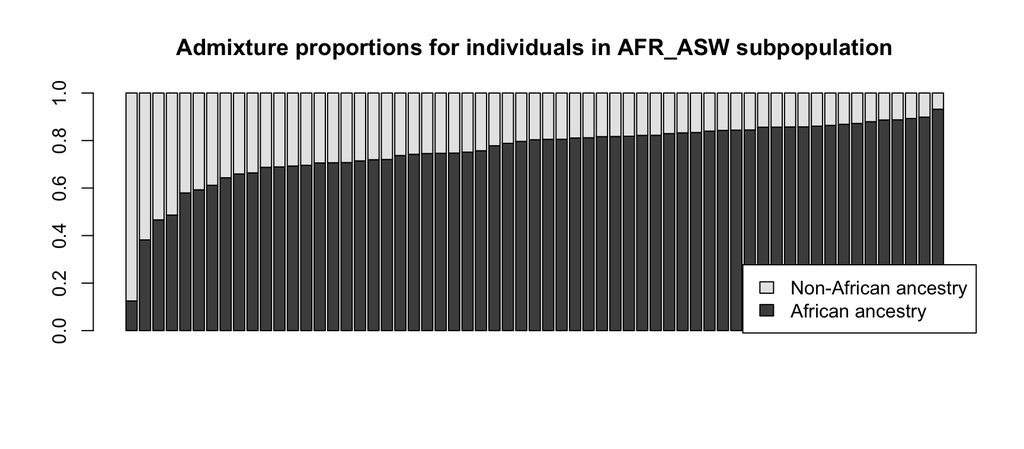

```r
## Barplot of admixture proportions for ASW subpopulation
barplot(asw_admix, legend=TRUE, args.legend=list(x="bottomright"),
        main="Admixture proportions for individuals in AFR_ASW subpopulation")
```

How about the AFR_ESN subpopulation?

```r
## Extract data and sort individuals
esn_admix = admix[, subPop=="AFR_ESN"]
esn_admix = esn_admix[, order(esn_admix[1,])]
```

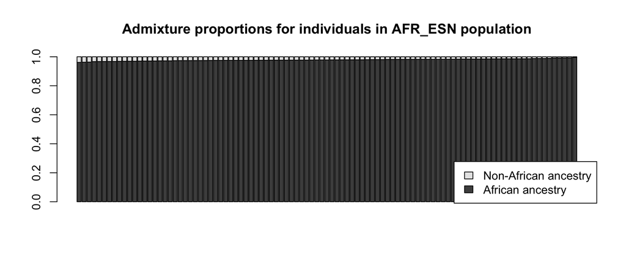

```r
## Barplot for AFR_ESN admixture
barplot(esn_admix, legend=TRUE, args.legend=list(x="bottomright"),
        main="Admixture proportions for individuals in AFR_ESN population")
```

## Assessment tasks

Use the data and code from above to answer the following questions. Hand in your code and the output generated, along with your answers to the questions below.

1. Select one of the seven SNPs from the first data set and investigate its variation (in terms of genotype frequencies) across the populations of the 1000 Genomes Project. Briefly overview the support for this SNP being a modifier of disease risk, and try to find evidence (in the literature) for variation in population-specific risk as a result of differences in genotype frequency.
2. Create a plot of PC1 *versus* PC2, colouring points by sub-population rather than super-population. Rather than use my `plotPCA` function, you will need to use R’s generic plotting commands. The following code generates a PCA plot from scratch, using the super-population colours:

```r
plot(pca[,1], pca[,2], col=popCol, pch=16, cex=0.5, xlim=1.5*range(pca[,1]))
legend("topright", legend=names(table(snpAns$Population)), fill=pCols, cex=0.5)

## Notes on parameters:
##  - "col" specifies the colors
##  - "pch" specifies the shape of the plotting symbol
##  - "cex" specifies the size of the points (or text, for the legend)
##  - "xlim" specifies the range of the x axis
##  - "fill" specifies the colours to be used in the legend
```

Loading the `subPopColours.RData` file via:

```r
load('subPopColours.RData')
```

will provide two colour objects: `spCols` and `subPopCol`, which you should be able to use to generate a PCA plot with the points coloured by sub-population.

Comment on the distribution of the sub-populations with respect to genetic variability. Which of the sub-populations exhibit evidence of admixture, and which populations (sub- or super-) are the most likely contributors? Is there support for these findings in the literature? Provide a brief summary of any relevant publications you find.

Generate similar plots of PC1 *versus* PC3 and PC2 *versus* PC3. Based on these plots, describe the main population features that are captured by each of the first three principal components.

3. Generate a phylogentic tree for the sub-population data. Comment on how well the structure of the tree agrees with the relationships between the super- and sub-populations of the 1000 Genomes Project data. Are there any super-populations that are split across different parts of the tree? If so, what is the likely cause? Discuss the shape of the tree (and the placement of the super- and sub-populations) in the context of the “out of Africa” theory of human migration. How does the shape of the tree support (or question) the proposed migration path? Also comment of the relationship between the shape of the tree, and the distribution of the populations in the PCA plot you generated in (2). What advantages and disadvantages do you feel the two plotting methods (PCA plot and phylogenetic tree) have when visualising genetic diversity data?
4. Use PC2 to investigate admixture involving European and East Asian ancestries. Choose two sub-populations whose members exhibit substantial variability in their admixture proportions for these ancestries, and provide summary information for each. Make admixture bar plots for these two sub-populations. Comment on the range of variation that is present, and discuss these results in the context of historical human migration patterns.
5. The Human Pangenome Reference Consortium is trying to build a reference pangenome which captures the full spectrum of genetic diversity across all human populations. A major component of this is the selection of appropriate samples. Discuss how plots of Principal Components could help with this process.